Statistics is the art to collect, to display, to analyze, and to interpret data in order to gain new knowledge. [Sachs 1999]

# Descriptive Statistics

Descriptive statistics summarizes the data and are broken into measures of central tendency(Mean, Median and Mode) and measures of variability(Standard deviation, Min/Max values, range, kurtosis and skewness)

**Measures of central tendency**

- **Mean** is the average value of the data.

[figure not shown]

- **Median** is the middle number of the data.

[figure not shown]

- **Mode** is the number that occurs most in the data.

**Measures of variability**

- **Standard deviation** tells how much deviation is present in the data, i.e. how spread out the numbers are from the mean value.

[figure not shown]

- **Variance** is closely related to standard deviation.Variance is just the square of the standard deviation

[figure not shown]

- **Minimum value** smallest number in the data.
- **Maximum value** largest number in the data.
- **Range** largest number – smallest number.
- **Kurtosis** is a measure of tailedness, it measures the sharpness of the peak.
- **Skew** is a measure of symmetry.

```python
# Importing required libraries

import pandas as pd
import numpy as np
```

```python
# Reading iris dataset

dataset = pd.read_csv('../dataset/iris.csv')
```

```python
# Viewing same dataset

dataset.head(5) # top 5 rows
```

|  | sepal_length | sepal_width | petal_length | petal_width | species |
| --- | --- | --- | --- | --- | --- |
| 0 | 5.1 | 3.5 | 1.4 | 0.2 | setosa |
| 1 | 4.9 | 3.0 | 1.4 | 0.2 | setosa |
| 2 | 4.7 | 3.2 | 1.3 | 0.2 | setosa |
| 3 | 4.6 | 3.1 | 1.5 | 0.2 | setosa |
| 4 | 5.0 | 3.6 | 1.4 | 0.2 | setosa |

```python
# statistical summary
# decribe() methods gives you a statistical summary (Mean, Standard Deviation, Min, Max, Range, 25%, 50%, 75% and count) of every column.

dataset.describe()
```

|  | sepal_length | sepal_width | petal_length | petal_width |
| --- | --- | --- | --- | --- |
| count | 150.000000 | 150.000000 | 150.000000 | 150.000000 |
| mean | 5.843333 | 3.054000 | 3.758667 | 1.198667 |
| std | 0.828066 | 0.433594 | 1.764420 | 0.763161 |
| min | 4.300000 | 2.000000 | 1.000000 | 0.100000 |
| 25% | 5.100000 | 2.800000 | 1.600000 | 0.300000 |
| 50% | 5.800000 | 3.000000 | 4.350000 | 1.300000 |
| 75% | 6.400000 | 3.300000 | 5.100000 | 1.800000 |
| max | 7.900000 | 4.400000 | 6.900000 | 2.500000 |

```python
# Lets work on some examples


# I want to find mean of sepal_width and store it in sepal_width_mean variable.

sepal_width_mean = dataset['sepal_width'].mean()
print('Sepal width mean is', sepal_width_mean)

# In order to calculate standard deviation and variance of petal_length. You can use .std() for standard deviation and .var() for variance


petal_length_sd = dataset['petal_length'].std()
print('petal Length Standard deviation is', petal_length_sd)


# To calculate variance

petal_length_var = dataset['petal_length'].var()
print('petal Length Variance is', petal_length_var)
```

```
Sepal width mean is 3.0540000000000007
petal Length Standard deviation is 1.7644204199522617
petal Length Variance is 3.1131794183445156
```

# Visualizing Characteristic Measures: Box Plots

A box plot is a common way to combine some important characteristic measures into a single graphic

[figure not shown]

A box plot is composed of a summary of 5 different data points: the minimum, first quartile, median, third quartile, and maximum.

```python
# for creating a beautiful box plot we required seaborn library

import seaborn as sns
```

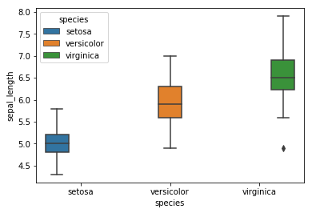

```python
sns.boxplot(x='species', y='sepal_length', data=dataset, hue='species')
```

So you can see based off of the box plots that the x data are the different species and the y data is the sepal length.

Box plots show range, median values, and outliers, along with quartile data.

By looks at the plots you can clearly say that **setosa(Median) < versocolor(Median) < Virginica(Median)**

you can find how does the data look like for different species for other measures

# Skewness

The skewness α3 (or skew for short) measures whether, and if, how much, a distribution differs from a symmetric distribution.

[figure not shown]

```python
# To find the skewness in the data we use .skew() method

sepal_length_skew = dataset['sepal_length'].skew()
print('Sepal Length skewness is', sepal_length_skew)
```

```
Sepal Length skewness is 0.3149109566369728
```

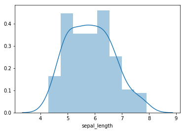

```python
sns.distplot(dataset['sepal_length'])
```

As you can see from the skewness is greater than 0. So, it steeps left and is clearly visible in plot. The distribution is left steep

# Kurtosis

The kurtosis or excess α4 measures how much a distribution is arched, usually compared to a Gaussian distribution.

[figure not shown]

```python
# To find the kurtosis in the data we use .kurtosis() method

sepal_length_kurtosis = dataset['sepal_length'].kurtosis()
print('Sepal Length Kurtosis is', sepal_length_kurtosis)
```

```
Sepal Length Kurtosis is -0.5520640413156395
```

Basically you can find your distribution of data by using shape measures such as **skewness** and **kurtosis**